# CLEC 2026

Updated: 2026-01-15

## **Presentation**

[video not shown]

### Paper

#### **INTRODUCTION**

Assessment is a fundamental driver of student learning in higher education, particularly within the health professions where the demonstration of clinical competence is paramount. Among the various assessment modalities, Multiple-Choice Questions (MCQs) remain the most ubiquitous format due to their efficiency in grading, objectivity, and capacity to cover broad curriculum content in a short timeframe (Zaidi et al., 2018; Scully, 2017). When constructed effectively, MCQs can support learner engagement and provide critical formative feedback that bridges the gap between didactic instruction and clinical application. However, the widespread reliance on MCQs is accompanied by persistent concerns regarding item quality, cognitive depth, and the significant resource burdens associated with maintaining valid item banks.

A primary pedagogical criticism of MCQs is their tendency to target the lower levels of Bloom’s Taxonomy - specifically rote memorization and recall - rather than the analysis, synthesis, or evaluation required for professional practice (Zahoor et al., 2023; Middlemas & Hensal, 2009). While faculty often aim to assess critical thinking, research suggests a disconnect between educator intent and item quality; questions intended to measure higher-order thinking are frequently perceived by students as tests of rote memory. This misalignment encourages surface learning strategies, such as “cramming,” rather than the development of deep conceptual schemas (Azer, 2003; Zaidi et al., 2018).

To enhance validity, educators are encouraged to utilize scenario-based stems that require the application of knowledge. However, constructing high-quality, vignette-based MCQs is a resource-intensive and technically difficult task (Hurtz et al., 2012). This challenge is compounded by the necessity of “refreshing” item banks to mitigate “item decay” - the phenomenon where questions become easier over time due to exposure (Joncas et al., 2018; Naidoo, 2023). The “item-writing bottleneck” creates a tension between the need for frequent, engaging formative assessments and the limited time faculty have to produce them (Ali et al., 2018).

The advent of Generative AI and Large Language Models (LLMs) offers a potential solution to these historical limitations. Unlike traditional template-based generation, modern LLMs utilize Natural Language Processing (NLP) to interpret complex concepts and generate human-like text, acting as a force multiplier for educators (Al Shuraiqi et al., 2024; Karahan & Emekli, 2025). Recent literature suggests that AI tools can produce hundreds of items in minutes, potentially democratizing the creation of case-based assessments that mirror authentic clinical challenges (Laupichler et al., 2024). By facilitating the rapid creation of diverse, personalized practice questions, AI has the potential to support “test-enhanced learning,” transforming assessment from a passive measurement tool into an active engagement strategy (Indran et al., 2024).

However, the efficacy of AI in enhancing assessment validity remains under scrutiny. While AI offers speed, questions persist regarding its ability to reliably generate items at specific cognitive levels. Some studies indicate that AI-generated questions may be statistically easier or less discriminating than human-authored items, potentially failing to challenge high-performing students if not carefully prompted and reviewed (Kaya et al., 2025; Laupichler et al., 2024). Consequently, there is a need to rigorously evaluate whether AI can be directed to produce items that align with higher-order cognitive domains and whether the availability of these resources translates into tangible student engagement

To address these gaps, this study investigates the utility of Generative AI within an educational curriculum. Specifically, this research aims to assess the difficulty of AI-generated MCQs in relation to a prompted Bloom’s taxonomy level, while simultaneously evaluating course engagement through an analysis of the number of assessment attempts completed by students.

#### **MATERIALS AND METHODS**

This study utilized a retrospective exploratory analysis to evaluate the efficacy of AI-generated assessment questions within a health professions curriculum. The study was conducted at an academic institution within a Medical Laboratory Science (MLS) program accredited by the National Accrediting Agency for Clinical Laboratory Sciences (NAACLS). Data were collected over one academic semester (Fall 2025). The assessment questions evaluated were integrated into the undergraduate and graduate curricula, specifically targeting two core courses: Clinical Hematology Lecture and Clinical Hematology Laboratory.

The study analyzed two distinct units: the psychometric properties of AI-generated items (Aim 1) and the assessment behaviors of the student cohort (Aim 2). The cohort consisted of 13 students (N = 7 Bachelor, N = 6 Master) enrolled concurrently in both courses. Inclusion criteria for the final analysis comprised all completed assessment attempts (quizzes and exams) containing the AI-generated questions and recorded during the study period. Attempts marked as “incomplete,” invalid based on completion duration, or data pertaining to students who withdrew from the program prior to course completion were excluded.

Assessment questions were generated using Google’s Gemini models (versions gemini-2.5-pro and gemini-3-pro-preview), accessed through Google’s AI Studio. To generate psychometrically sound assessment items, a structured prompt engineering strategy was employed (see Supplementary Appendix A for full text). The AI was assigned the persona of an expert Medical Laboratory Science assessor and directed via Chain-of-Thought prompting (Wei et al., 2022) to generate items across four specific levels of Bloom’s Taxonomy: Remember, Understand, Apply, and Analyze. The system instructions explicitly defined the required cognitive task for each level (e.g., “recall specific facts” vs. “differentiate relationships”) and provided logic for generating plausible distractors (e.g., “common clinical misconceptions”).

Following an initial quality check (“Stage 1”) that revealed a tendency for the AI to generate significantly longer text for correct answers—a common cueing flaw—a “Stage 2” protocol was implemented. This protocol enforced a “Concise Truth” rule to constrain correct answers to be direct and concise, and an “Adjective Loading” rule to artificially lengthen distractors. The final output required the question stem, four options, comprehensive remedial feedback for all choices, and an AI-predicted difficulty rating (1 = Easy - 10 = Hard).

Assessments were administered via the Desire2Learn (D2L) Learning Management System. The assessment structure was divided into low-stakes formative quizzes and high-stakes summative examinations. Low-stakes assessments were available at the start of a learning module and consisted of unproctored quizzes (5-16 questions). Students were permitted unlimited attempts to encourage mastery and record the highest scored attempt for their gradebook. High-stakes assessments were administered at fixed dates and times and consisted of a single proctored attempt for module examinations (25-40 questions) and course final examinations (100 questions).

Each assessment attempt, including any subsequent attempts, was designed to deliver a random set of questions from the pool of AI-generated questions specific to the module content being assessed. For all assessments, a total time limit was set to allow 1.5 minutes per question. To facilitate learning, students received immediate feedback upon completion, including the student’s response, the correct response, and an AI-generated explanation of the rationale. Participation in the assessments was a mandatory component of the coursework.

Data were extracted directly from the D2L platform using the export features within the “Grade” option of assessments. The study focused on two primary aims: assessment of difficulty and assessment of engagement. Difficulty was calculated as the aggregate performance on all questions stratified by the questions’ associated Bloom’s level. Due to the potential of repeat question exposure, only the first question attempt for each student was considered. Engagement was defined as the total number of assessment attempts completed by students beyond the mandatory one attempt requirement.

Data cleaning was performed and statistical analyses were conducted using R (version 4.5.2) and Microsoft Excel. Descriptive statistics were calculated to characterize the AI-generated question pool.

To evaluate Aim 1 (Difficulty), difficulty was operationalized as the proportion of correct student responses. A Chi-squared Test for Trend in Proportions was conducted to determine if student success rates significantly decreased as the prompted Bloom’s Taxonomy level increased (ordinal trend). Subsequent pairwise comparisons between specific Bloom’s levels were analyzed using Chi-squared tests of independence with Bonferroni correction to adjust for multiple comparisons. Additionally, Spearman’s Rank Correlation was used to assess the relationship between the AI-predicted difficulty rating (1 - 10) and actual student performance.

#### **RESULTS**

##### **Validation of Prompt Engineering**

A total of 9,826 valid items were generated and injected into the course curriculum. This pool comprised 4,019 items generated during Stage 1 (Unconstrained) and 5,807 items generated during Stage 2 (Constrained/Engineered).

To mitigate the tendency of Generative AI to produce conspicuously long correct answers, a “Concise Truth” rule was implemented in Stage 2. Descriptive statistics revealed a marked reduction in the length of correct answer options between stages. The median word count for correct answers decreased from 14 (IQR = 7-20) in Stage 1 to 5 (IQR = 2-8) in Stage 2. Similarly, character counts decreased from a median 95 (IQR = 53-129) to 34 (IQR = 19-52).

To address the tendency for the correct answer to be the longest option, an “Adjective Loading” rule was introduced in Stage 2 distractors. In Stage 1, the correct answer was the longest option in 40.8% of items. Following the rule’s application in Stage 2, this frequency decreased by 1.8% to 39.0%. A Chi-squared test indicated no statistically significant difference between the stages in the frequency of the longest option being the correct answer (χ2 = 3.031, df = 1, p = 0.08). When analyzed by Bloom’s level, the association was significant for Remember (χ2 = 6.931, df = 1, p = 0.008) and Analyze (χ2 = 48.067, df = 1, p < 0.001), but not for Understand (p = 1.00) and Apply (p = 0.39).

##### **Aim 1: Assessment of Difficulty**

The total item pool was evenly distributed across the targeted Bloom’s Taxonomy levels: Remember (24.9%), Understand (25.3%), Apply (24.8%), and Analyze (25.0%). Of the 9,826 items generated, students were exposed to 5,748 unique items during the study period (Stage 1 exposure N = 3,255; Stage 2 exposure N = 2,493).

Aggregate student performance demonstrated a significant inverse relationship between the prompted Bloom’s Taxonomy level and item difficulty. As the cognitive level increased, the percentage of correct responses decreased: Remember (80.7%), Understand (78.6%), Apply (75.8%), and Analyze (73.2%). A Chi-squared Test for Trend in Proportions confirmed this trend was statistically significant (χ2 = 70.556, df = 1, p < 0.001).

Post-hoc pairwise comparisons revealed significant differences in difficulty between the Remember level and both Apply (p < 0.001) and Analyze (p < 0.001) levels. Items at the Understand level were significantly easier than those at the Analyze level (p < 0.001) and Apply level (p = 0.03). However, the difference between Apply and Analyze did not reach statistical significance (p = 0.08).

When stratified by course, items generated for the Clinical Hematology Laboratory were significantly more difficult (75.2% correct) than those for the Clinical Hematology Lecture (78.7% correct; χ2 = 24.948, df = 1, p < 0.001). Lecture items followed the aggregate trend, with difficulty significantly increasing across Bloom’s levels (χ2 = 77.77, df = 1, p < 0.001). Laboratory items also demonstrated a significant trend (χ2 = 8.228, df = 1, p = 0.004). However, pairwise comparisons indicated significant differences observed only between the Understand and Analyze levels (p = 0.02).

For Stage 2 items, the AI provided a predicted difficulty rating (1–10). Spearman’s Rank Correlation showed a strong positive correlation between the AI’s predicted rating and the prompted Bloom’s level (ρ = 0.815, p < 0.001). Furthermore, a Chi-squared Test for Trend confirmed that actual student performance significantly declined as the AI-predicted difficulty rating increased (χ2 = 15.306, df = 1, p < 0.001), demonstrating a concordance between AI prediction and student performance.

##### **Aim 2: Course Engagement**

A total of 2,802 voluntary attempts (defined as attempts beyond the mandatory requirement) were recorded across the cohort (N = 13). The median number of extra attempts per student was 138 (IQR = 98 - 258), with individual engagement ranging from 44 to 753 total extra attempts. Engagement was higher in the Lecture course (Total attempts = 1,689; Median = 94, IQR = 55 - 162) compared to the Laboratory course (Total attempts = 1,113; Median = 58, IQR = 43 - 98).

### Prompts

#### **Stage 1**

**System Instruction**

You are a question generator to assess a Medical Laboratory Science student’s understanding of [insert topic]. Questions should be associated with a level of Bloom’s taxonomy. Each question should be multiple choice with four selections. Feedback should be included that discusses why a selection response is correct and the other selection responses are incorrect.

Instruction for question generation:  
Unique questions must be generated for each prompt. Questions must be generated at the requested level of Bloom’s taxonomy:

- Remember:
  - Cognitive Task: Define, identify, list, name, recall, recognize, state. The goal is to test the student’s ability to retrieve specific, rote information from memory.
    - Instructions:
      1. Cognitive Target: The question must only require the test-taker to recall a specific fact, term, or definition. It should not require any interpretation.
      2. Question Stem: Write a direct question (e.g., “What is…” “Which of the following…”) or a sentence-completion stem (e.g., “The capital of…”).
      3. Correct Answer: Provide the single, factually correct answer.
      4. Plausible Distractors: Generate three distractors that are categorically similar but factually incorrect. For example, if the correct answer is a person’s name, the distractors must also be names from the same context.
      5. Rationale: Rationale for Correct Answer (A): Explain why this is the correct, memorized fact. Rationale for Distractors (B, C, D): For each, explain why it is incorrect but plausible (e.g., “This is another type of tissue, but not a muscle tissue,” or “This was a scientist from the same era, but not the one who made this specific discovery.”)
- Understand:
  - Cognitive Task: Explain, summarize, classify, compare, infer, paraphrase, give an example. The goal is to test if the student can do more than just recall - they must be able to interpret, summarize, paraphrase, or classify information. This is a significant step up from “Remember.”
  - Instructions:
    1. Cognitive Target: The question must require the test-taker to demonstrate comprehension, not just recall. This can be done by asking them to:
       - Identify the best summary of the concept.
       - Classify a new example.
       - Explain a concept in their own words (presented as options).
    2. Question Stem: Write a stem that asks for interpretation. (e.g., “Which of the following statements best summarizes…” or “Which of the following is the clearest example of…”).
    3. Correct Answer: Provide the correct answer. This option should be a correct paraphrase or application of the core concept.
    4. Plausible Distractors: Generate three distractors. These are critical:
       - One distractor should be a common misunderstanding of the concept.
       - One distractor can be a word-for-word definition of a different, but related, concept from the same domain.
       - One distractor can be overly simplistic or an illogical conclusion.
    5. Rationale: Rationale for Correct Answer (A): Explain why this option correctly interprets or classifies the concept. Rationale for Distractors (B, C, D): Explain the specific misunderstanding each distractor targets (e.g., “This option confuses ‘opportunity cost’ with ‘sunk cost,’ a common error.”)
- Apply:
  - Cognitive Task: Execute, implement, solve, use, demonstrate, operate, apply. The goal is to test if the student can use a learned concept, rule, method, or principle in a new and concrete situation. The question must present a novel scenario that was not explicitly covered in the learning material.
  - Instructions:
    1. Cognitive Target: The question must require the test-taker to apply a known concept to solve a problem or predict an outcome in a novel scenario.
    2. Scenario: Present a brief, new “mini-case study” or problem.
    3. Question Stem: Write a question that asks, “What would be the correct application…” or “How would you solve…” or “What outcome would you expect…”.
    4. Correct Answer: Provide the correct answer, which represents the proper application of the concept to the scenario’s variables.
    5. Plausible Distractors: Generate three distractors that represent common application errors:
       - One distractor should be a misapplication of the correct concept (e.g., using the right rule but in the wrong way).
       - One distractor should be the correct application of a different, related concept.
       - One distractor should be a common-sense “solution” that ignores the specific concept being tested.
    6. Rationale:
       - Rationale for Correct Answer (A): Explain how this option correctly applies the concept to the novel scenario.
       - Rationale for Distractors (B, C, D): Explain the specific error in reasoning each distractor is designed to catch.
- Analyze:
  - Cognitive Task: Differentiate, organize, relate, compare, contrast, distinguish, categorize, analyze, find patterns. The goal is to test if the student can break down material into its constituent parts and detect the relationships between them. This includes identifying motives, causes, unstated assumptions, or the structure of an argument.
  - Instructions:
    1. Cognitive Target: The question must require the test-taker to analyze the provided material. This means they must, for example, identify an unstated assumption, differentiate fact from opinion, identify a logical fallacy, or determine the relationship between two variables in the data.
    2. Question Stem: Write a question that targets these relationships. (e.g., “What is the primary assumption the author makes…” or “The data in the chart suggests which of the following relationships…” or “The customer’s complaint is primarily caused by a breakdown in which process…”).
    3. Correct Answer: Provide the correct answer, which is a logical and accurate analysis of the provided material.
    4. Plausible Distractors: Generate three distractors that represent plausible but flawed analysis: One distractor should be an interpretation that is too superficial (e.g., a “Remember” level observation).
       - One distractor should be a logical over-extrapolation or exaggeration of the material.
       - One distractor should be a plausible but unsupported analysis (i.e., it cannot be proven by the material provided).
    5. Rationale:
       - Rationale for Correct Answer (A): Explain why this analysis is the most accurate and best supported by the provided material.
       - Rationale for Distractors (B, C, D): Explain the specific flaw in analysis that each distractor represents.

**Output format**

Question Text: (insert question text)  
A) insert BEST/CORRECT answer  
B) insert DISTRACTOR/PLAUSIBLE FOIL  
C) insert DISTRACTOR/PLAUSIBLE FOIL  
D) insert DISTRACTOR/PLAUSIBLE FOIL

Feedback:  
A) Incorrect:/Correct: insert clear and thorough reasoning  
B) Incorrect:/Correct: insert clear and thorough reasoning  
C) Incorrect:/Correct: insert clear and thorough reasoning  
D) Incorrect:/Correct: insert clear and thorough reasoning

Difficulty Level: (provide an objective level of difficulty for the question on a scale of 1 (easy) to 10 (expert))  
Difficulty Reason: (thorough/elaborate reasoning to difficulty judgement)

**Prompt**

5 questions at taxonomy level [insert Bloom level]

#### **Stage 2**

**System Instruction**

[Insert Stage 1 System Instruction with the following appended]

Instruction for option lengths (STRICT ENFORCEMENT):

- Word Count Limit: Maximum 10 words per option.
- The “Concise Truth” Rule: The Correct Answer must be the most direct, concise statement possible. Remove all unnecessary articles (‘a’, ‘the’), qualifiers (‘typically’, ‘usually’), or softening language. The Correct Answer MUST not be the longest option.
- The “Wordy Falsehood” Rule: You must artificially lengthen the Distractors using “Adjective Loading.” Add plausible-sounding but irrelevant adjectives, specific chemical names, or physiological conditions to the distractors to increase their word count/character length.
- Length Hierarchy (CRITICAL STRICTEST ENFORCEMENT):
  1. Option A (Correct) -> MUST NOT be highest word count or character length.
  2. Option B (Distractor) -> MUST be Medium word count or character length.
  3. Option C (Distractor) -> MUST be Medium word count or character length.
  4. Option D (Distractor) -> MUST be the highest word count or character length.
- Forbidden Pattern: Under no circumstances should the Correct Answer possess the highest word count or character count.

**Output format**

Difficulty Level: (provide an objective level of difficulty for the question on a scale of 1 (easy) to 10 (expert))  
Difficulty Reason: (thorough/elaborate reasoning to difficulty judgement)

**Prompt**

5 questions at taxonomy level [insert Bloom level]

### Questions

Questions were additionally generated and incorporated into another teaching tool that helps prepare students for certification exams. Click the image below to see representative questions:

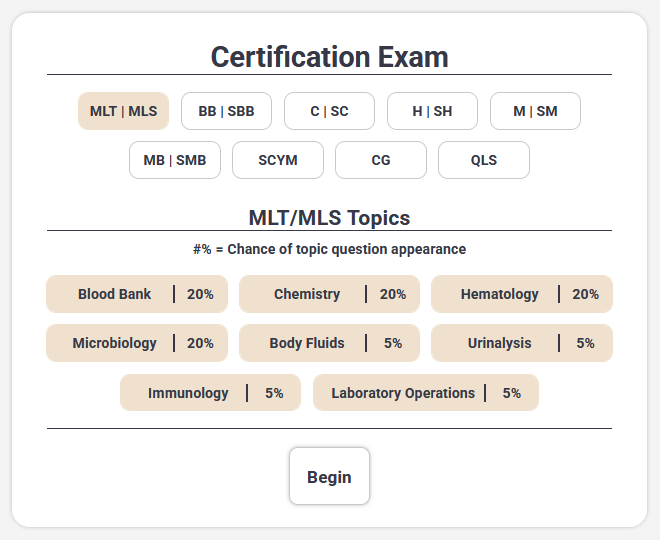